# Half Pounder Genotyping Notebook

## QAQC

### Controls

First let’s check that the controls worked well. We will check that negative controls have much fewer reads than average (there may be some on-target reads from otehr samples due to index sequence error)

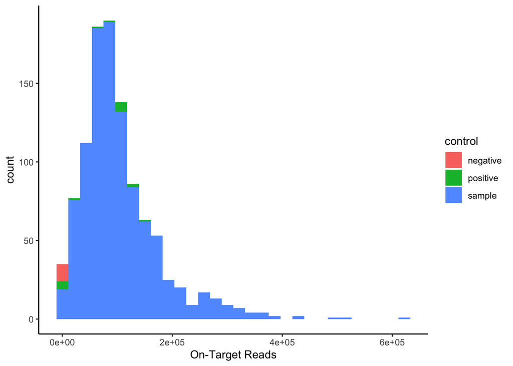

```r
#first I cleaned up the sample names with regex in a text editor - separated adapter info from sample name
genos_0.1 <- read_csv("genotype_data/half_pounder_GTs_0.1.csv")

#lets set a value to mark controls
genos_0.1 <- genos_0.1 %>%
  mutate(control = ifelse(grepl("positive", Sample), "positive", ifelse(grepl("negative", Sample), "negative", "sample")))

ggplot()+geom_histogram(data = genos_0.1, aes(x = `On-Target Reads`, fill= control)) + theme_classic()
```

Looks good, but lets just double check there is a negative with a lot of reads hiding in there and indicating a plate flip:

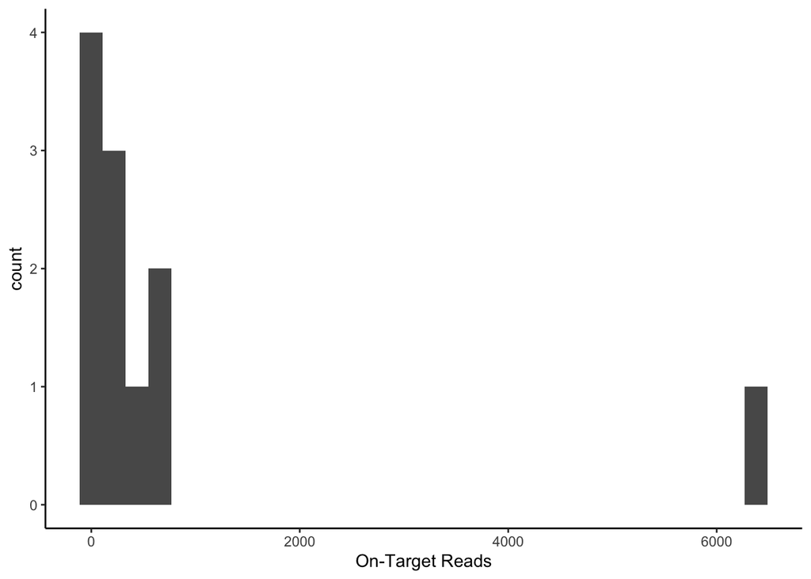

```r
ggplot()+geom_histogram(data = genos_0.1[genos_0.1$control=="negative",], aes(x = `On-Target Reads`)) + theme_classic()
```

Uh-oh a negative control with ~6300 on target reads, but maybe there’s just a lot of reads at this adapter/well, lets examine as a portion of total reads

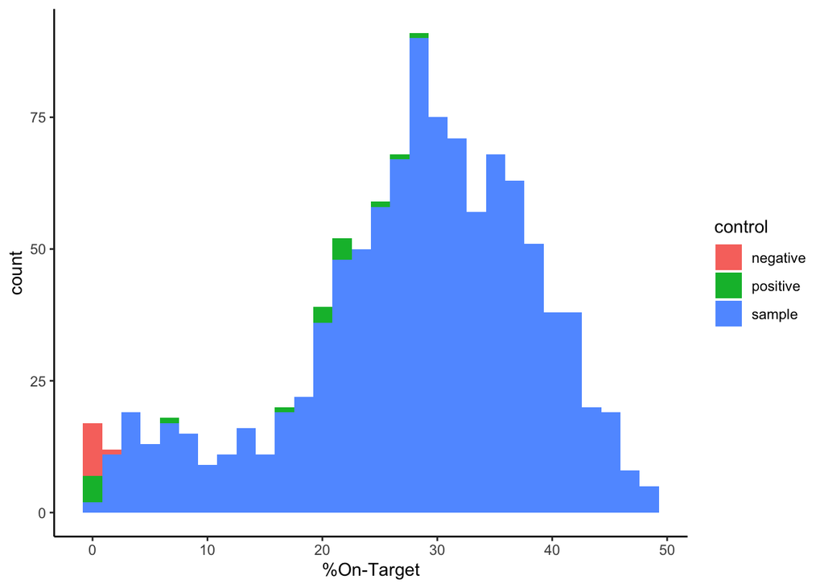

```r
ggplot()+geom_histogram(data = genos_0.1, aes(x = `%On-Target`, fill= control)) + theme_classic()
```

Okay, that looks a lot better. Positive and negative controls check out.